# Graph Testing Vignette

Julia Fukuyama

2024-02-05

## Overview

Suppose we have collected measurements about bacterial abundances from a number of samples, and those samples fall into one of several groups. We want to know if there is a statistically significant difference between the groups, that is, whether it looks like the microbiome samples from the different groups look like they could all have come from all come from the same distribution.

One good non-parametric family of tests for this problem is based on the Friedman-Rafsky[^1] test. The idea is to compute distances between the samples, create a graph based on those distances, and use the number of edges between samples of the same type (the number of “pure edges”) as a test statistic. We can then compute a $p$-value by comparing the observed test statistic to the distribution of the test statistic under the permutation distribution.

From the description above, we see that we have some choices to make. We need to define a distance between the samples and choose a method for creating a graph from those distances. These choices are responsible for most of the arguments to `graph_perm_test`, the primary function in this package.

## Specifying a distance

The `distance` argument in `graph_perm_test` allows you to specify a distance. This can be any distance implemented in `phyloseq`, and it should be taken from the following list:

```r
library(phyloseq)
unlist(distanceMethodList)
```

```
##     UniFrac1     UniFrac2        DPCoA          JSD     vegdist1     vegdist2
##    "unifrac"   "wunifrac"      "dpcoa"        "jsd"  "manhattan"  "euclidean"
##     vegdist3     vegdist4     vegdist5     vegdist6     vegdist7     vegdist8
##   "canberra"       "bray" "kulczynski"    "jaccard"      "gower"   "altGower"
##     vegdist9    vegdist10    vegdist11    vegdist12    vegdist13    vegdist14
##   "morisita"       "horn"  "mountford"       "raup"   "binomial"       "chao"
##    vegdist15   betadiver1   betadiver2   betadiver3   betadiver4   betadiver5
##        "cao"          "w"         "-1"          "c"         "wb"          "r"
##   betadiver6   betadiver7   betadiver8   betadiver9  betadiver10  betadiver11
##          "I"          "e"          "t"         "me"          "j"        "sor"
##  betadiver12  betadiver13  betadiver14  betadiver15  betadiver16  betadiver17
##          "m"         "-2"         "co"         "cc"          "g"         "-3"
##  betadiver18  betadiver19  betadiver20  betadiver21  betadiver22  betadiver23
##          "l"         "19"         "hk"        "rlb"        "sim"         "gl"
##  betadiver24        dist1        dist2        dist3   designdist
##          "z"    "maximum"     "binary"  "minkowski"        "ANY"
```

You can see the help page on [distances](https://joey711.github.io/phyloseq/distance.html) for more information. The distance should be chosen carefully and should reflect the type of differences between samples you are interested in.

## Specifying a type of graph

`graph_perm_test` allows you to specify one of four options for a type of graph: a minimum spanning tree, a $k$-nearest neighbors graph, and two types of thresholded graphs. These are passed to the `type` argument.

- `type = "mst"` creates a [minimum spanning tree](https://en.wikipedia.org/wiki/Minimum_spanning_tree). The minimum spanning tree places edges between the samples so that all of the samples are connected and the sum of the distances between samples connected by an edge is minimized.
- `type = "knn"` creates a $k$-nearest neighbors graph. For each sample, we place an edge between it and its $k$ nearest neighbors. This of course requires you to specify $k$ with the argument `knn`. A small number, on the order of 1 to 3 is likely a good choice.
- `type = "threshold.distance"` creates a distance threshold graph, and requires you to specify `max.dist`. The graph will be created by placing an edge between any pair of points where the distance between them is less than `max.dist`.
- `type = "threshold.nedges"` creates a distance threshold graph, and requires you to specify `nedges`. The graph will be created by computing distances between every pair of samples, and placing an edge between the `nedges` pairs of samples with the smallest distances between them.

Note that the `knn` argument is only used with `type = "knn"`, the `max.dist` argument is only used if `type = "threshold.distance"`, and the `nedges` argument is only used if `type = "threshold.nedges"`. `type = "mst"` requires no additional arguments.

In some [simulations](https://jfukuyama.github.io/software/graph_testing_poster.pdf) we saw that the minimum spanning tree and k-nearest neighbors had the most power. The minimum spanning tree is the simplest choice since it doesn’t require specifying any further parameters, but if you have reason to believe that other types of graphs would be more appropriate in your application they are also available. The $k$-nearest neighbors graph might be desirable because it gives an interpretable test statistic: the number of nearest neighbors that are of the same type.

## Running a test

Suppose that we have collected the data in the `enterotype` dataset, which is available in the phyloseq package as a `phyloseq` object. We can load the data and look at it with the following commands:

```r
library(ggplot2)
# not necessary, but I like the white background with ggplot
theme_set(theme_bw())
library(phyloseqGraphTest)
data(enterotype)
enterotype
```

```
## phyloseq-class experiment-level object
## otu_table()   OTU Table:         [ 553 taxa and 280 samples ]
## sample_data() Sample Data:       [ 280 samples by 9 sample variables ]
## tax_table()   Taxonomy Table:    [ 553 taxa by 1 taxonomic ranks ]
```

Suppose we want to test for differences between sequencing platforms (the `SeqTech` column in the sample data). We have also decided we want to use the Jaccard dissimilarity and a $k$-nearest neighbors graph with $k$ = 1 to perform our test. Then we would use the following commands to run the test and view the output:

```r
gt = graph_perm_test(enterotype,
                     sampletype = "SeqTech",
                     distance = "jaccard",
                     type = "knn",
                     knn = 1)
gt
```

```
## Output from graph_perm_test
## ---------------------------
## Observed test statistic: 197 pure edges
## 221 total edges in the graph
## Permutation p-value: 0.002
```

We see that the difference between sequencenig platforms is statistically significant, with a $p$-value of .002. The effect is also quite substantial: we see from the observed test statistic that out of the 221 total edges in the 1-nearest neighbors graph, 197 of them connect samples of the same type.

## Detailed output from the test

The output from `graph_perm_test` is a `psgraphtest` object, which is a list containing information about the test. The elements of the list are:

- `observed`: The observed test statistic, the number of pure edges.
- `perm`: A vector containing the value of the test statistic (the number of pure edges) in each of the permuted datasets.
- `pval`: The p-value for the permutation test. This is the fraction of times the number of pure edges in the permuted dataset exceeded the number of pure edges in the observed dataset.
- `net`: The graph used for testing.
- `sampletype`: A vector containing the group label for each sample.
- `type`: The type of graph used.

These can be inspected by hand, but the package also contains some functions for plotting the results.

## Plotting the results of the test

The function `plot_test_network` plots the graph we created on the samples, the sample identities, and the edge types (pure or mixed, i.e. edges between samples of the same type or edges between samples of different types). Here we see that the nearest neighbor graph connects largely samples of the same type.

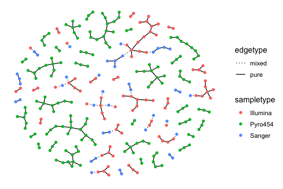

```r
plot_test_network(gt)
```

The function `plot_permutations` will plot a histogram of the number of pure edges in each of the permuted datasets along with the number of pure edges in the observed dataset. For this dataset, we see that the number of pure edges in the observed dataset is well outside of the permutation distribution.

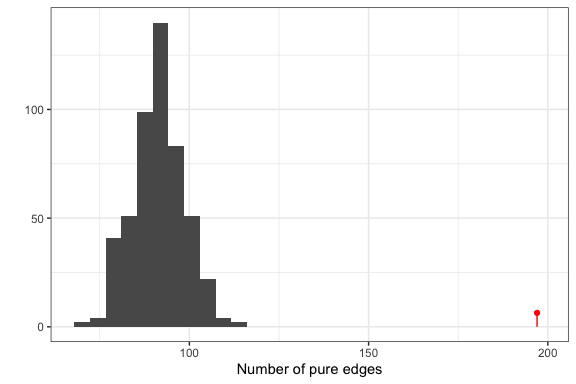

```r
plot_permutations(gt)
```

## Additional arguments

There are a couple of other arguments to the `graph_perm_test` function. `nperm` is the number of permutations to use for the test. The default is 499, and it can be increased or decreased depending on how much computational time you have and how closely you want to approximate the full permutation distribution.

You can also specify a stratifying variable using the `grouping` argument. This is necessary in repeated measures designs. Suppose for instance that we have mice in two different litters, and we would like to test for equality of the distributions from the two litters. If we have more than one sample taken from each of the mice, permuting the litter label over all the samples independently will not give a valid test because of the dependence between samples taken from the same mouse. We can fix this by considering the mice the independent units and permuting the litter label over mouse instead of over sample to obtain a valid test.

[^1]: Friedman, J.H. and Rafsky, L.C. “Multivariate generalizations of the Wald-Wolfowitz and Smirnov two-sample tests.” The Annals of Statistics (1979):697-717.